[figure not shown]

# Algoritmos de [OSMnx](https://geoffboeing.com/2016/11/osmnx-python-street-networks/) para construir, proyectar, visualizar y analizar la red vial del Municipio Libertador - Caracas mediante el modelado de redes de trasporte, cálculo de estadísticas y la orientación media con datos de [OpenStreetMap](https://www.openstreetmap.org/#map=11/10.5061/-66.9146) y el API de [GoogleMaps](https://developers.google.com/maps/documentation/elevation/intro?hl=es-419).

[Roque Leal](https://roqueleal.me)

Nuevos algoritmos como OSMnx nos presentan una serie de indicadores que ayudan a definir la lógica espacial y el orden urbano, revelando el orden y el desorden de las calles, así como las mejores estrategias de la dinámica del transporte de una ciudad. En esta oportunidad exploraremos el Municipio Libertador utilizando datos de OpenStreetMap y OSMnx en una primra oportunidad para conocer la red vial y ejecutar un modelado de rutas basado en las distancias y la impendancia y finalmente aplicar el indicador de orientación de las ciudades a manera de cuantificar cómo la red vial en Caracas sigue una lógica de ordenamiento geométrico de una cuadrícula única ó su patrón es heterogéneo.

## Recursos:

1.- Datos del API de OpenStreetMap para descargar los datos de la red.

2.- Datos del API de Google Maps para descargar los datos de altitud y asociarlos a la red vial, para desarrollar nuestro modelo de impendancias, definido este por la diferencia altitudinal de las rutas.

3.- Aplicar el algoristmo de OSMnx para desarrollar los modelos y definir las orientaciones cardinales de los ejes viales.

## Importamos las librerias

```python
from api import APIKey
import networkx as nx
import numpy as np
import osmnx as ox
import matplotlib.pyplot as plt
import pandas as pd
%matplotlib inline
ox.config(log_console=True, use_cache=True)
ox.__version__
```

```
'0.11.4'
```

```python
# Extraemos los datos asociados al municipio Libertador: Caracas
place = 'Municipio Libertador'
G = ox.graph_from_place('Municipio Libertador, Venezuela', network_type='drive', which_result=5)
```

```python
# Consultamos los datos para cada nodo vial extraido utilizando los datos de Google Elevation API
G = ox.add_node_elevations(G, api_key=APIKey)
G = ox.add_edge_grades(G)
```

## Calculamos las variaciones de pendiente de la red vial

Usamos los nodos para definir la red y solo tomamos los valores únicos para evitar duplicar los datos y finalmente calculamos los valores porcentuales de pendiente.

```python
edge_grades = [data['grade_abs'] for u, v, k, data in ox.get_undirected(G).edges(keys=True, data=True)]
```

```python
avg_grade = np.mean(edge_grades)
print('Pendiente Promedio de la red vial en Caracas  {} is {:.1f}%'.format(place, avg_grade*100))

med_grade = np.median(edge_grades)
print('Mediana de la pendiente de la red vial en Caracas {} is {:.1f}%'.format(place, med_grade*100))
```

```
Pendiente Promedio de la red vial en Caracas  Municipio Libertador is 6.5%
Mediana de la pendiente de la red vial en Caracas Municipio Libertador is 4.2%
```

Comparemos estos datos con el [Guia de Diseno de Infraestructura y Equipamiento Ciclista](https://arquitectura.unam.mx/uploads/8/1/1/0/8110907/guia-diseno-infraestructura.pdf) elaborado por la Facultad de Arquitectura de la UNAM - México

[figure not shown]

Vemos que en promedio el Municipio Libertador cuenta con una condición Normal para el desarrollo de una infraestructura de Ciclovia si bien lo ideal sería contar con valores cercanos a 1% en pendiente, la actual estructura vial ofrece condiciones igualmente favorables para su planificación, para ello a continuación visualizaremos la red elaborando un modelo de impendancia por la condición altitudinal.

## Visualizando los nodos viales y su altitud

Siendo los valores de menor altitud violeta y los de mayor altitud amarillo.

```python
G_proj = ox.project_graph(G)
```

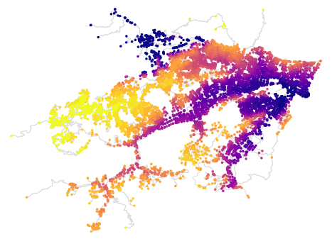

```python
nc = ox.get_node_colors_by_attr(G_proj, 'elevation', cmap='plasma', num_bins=20)
fig, ax = ox.plot_graph(G_proj, fig_height=6, node_color=nc, node_size=12, node_zorder=2, edge_color='#dddddd')
```

## Se incorporan los valores de Altitud a la red vial del Municipio Libertador para visualizar nuestro modelo de impendancias

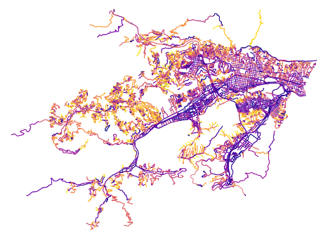

```python
# get a color for each edge, by grade, then plot the network
ec = ox.get_edge_colors_by_attr(G_proj, 'grade_abs', cmap='plasma', num_bins=100)
fig, ax = ox.plot_graph(G_proj, fig_height=6, edge_color=ec, edge_linewidth=0.8, node_size=0)
```

## Ejecutamos el Modelo de Impendancias definiendo una ruta para calcular la ruta más corta y la ruta con menor pendiente

```python
# Seleccionamos una ruta en la ciudad de Caracas
origin = ox.get_nearest_node(G, (10.501716,-66.946971))
destination = ox.get_nearest_node(G, (10.506104,-66.914742))
bbox = ox.bbox_from_point((10.510113,-66.931951), distance=3000, project_utm=True)
```

```python
# Definimos nuestro modelo basado en la distancia y las variaciones de pendiente
def impedance(length, grade):
    penalty = grade ** 2
    return length * penalty


for u, v, k, data in G_proj.edges(keys=True, data=True):
    data['impedance'] = impedance(data['length'], data['grade_abs'])
    data['rise'] = data['length'] * data['grade']
```

#### Ruta más corta:

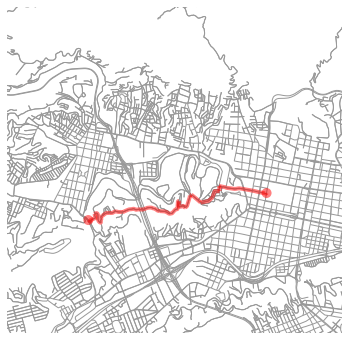

```python
route_by_length = nx.shortest_path(G_proj, source=origin, target=destination, weight='length')
fig, ax = ox.plot_graph_route(G_proj, route_by_length, bbox=bbox, node_size=0)
```

#### Ruta con menor pendiente:

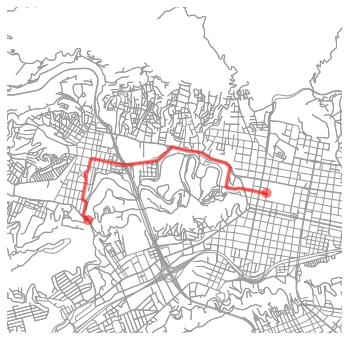

```python
route_by_impedance = nx.shortest_path(G_proj, source=origin, target=destination, weight='impedance')
fig, ax = ox.plot_graph_route(G_proj, route_by_impedance, bbox=bbox, node_size=0)
```

#### Cálculemos los estadísticas para ambas rutas:

```python
def print_route_stats(route):
    route_grades = ox.get_route_edge_attributes(G_proj, route, 'grade_abs')
    msg = 'The average grade is {:.1f}% and the max is {:.1f}%'
    print(msg.format(np.mean(route_grades)*100, np.max(route_grades)*100))

    route_rises = ox.get_route_edge_attributes(G_proj, route, 'rise')
    ascent = np.sum([rise for rise in route_rises if rise >= 0])
    descent = np.sum([rise for rise in route_rises if rise < 0])
    msg = 'Total elevation change is {:.0f} meters: a {:.0f} meter ascent and a {:.0f} meter descent'
    print(msg.format(np.sum(route_rises), ascent, abs(descent)))

    route_lengths = ox.get_route_edge_attributes(G_proj, route, 'length')
    print('Total trip distance: {:,.0f} meters'.format(np.sum(route_lengths)))
```

```python
# Estadísticas de la ruta más corta
print_route_stats(route_by_length)
```

```
The average grade is 6.6% and the max is 19.2%
Total elevation change is -85 meters: a 98 meter ascent and a 183 meter descent
Total trip distance: 4,540 meters
```

```python
# Estadísticas para la ruta con la menor pendiente
print_route_stats(route_by_impedance)
```

```
The average grade is 2.6% and the max is 11.1%
Total elevation change is -85 meters: a 13 meter ascent and a 98 meter descent
Total trip distance: 5,365 meters
```

## La orientación de la red vial como un nuevo indicador de la lógica urbana de nuestras ciudades

### Calculamos las orientaciones y analizamos su frecuencia

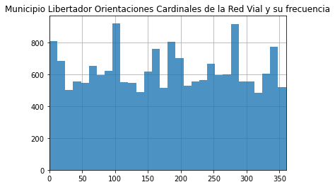

```python
G = ox.add_edge_bearings(G)
bearings = pd.Series([data['bearing'] for u, v, k, data in G.edges(keys=True, data=True)])
ax = bearings.hist(bins=30, zorder=2, alpha=0.8)
xlim = ax.set_xlim(0, 360)
ax.set_title('Municipio Libertador Orientaciones Cardinales de la Red Vial y su frecuencia')
plt.show()
```

Creamos un histograma polar dónde cada barra representará la dirección de las calles con relación a los puntos cardinales (Norte, Sur, Este y Oeste) y su longitud representará la cantidad de calles en una dirección concreta.

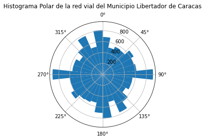

```python
import numpy as np
n = 30
count, division = np.histogram(bearings, bins=[ang*360/n for ang in range(0,n+1)])
division = division[0:-1]
width =  2 * np.pi/n
ax = plt.subplot(111, projection='polar')
ax.set_theta_zero_location('N')
ax.set_theta_direction('clockwise')
bars = ax.bar(division * np.pi/180 - width * 0.5 , count, width=width, bottom=0.0)
ax.set_title('Histograma Polar de la red vial del Municipio Libertador de Caracas', y=1.1)
plt.show()
```

Este histograma nos permite dimensionar la heterogeneidad de la red vial, sin embargo en su mayoria es posible observar que la red obedece a un patrón Este-Oeste definido principalemente por la Avenida Bolívar y sus calles paralelas, veamos un escenario más homogéneo como lo es el Municipio Chacao.

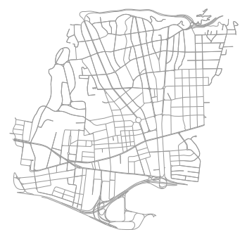

```python
G = ox.graph_from_place('Chacao, Caracas, Venezuela', network_type='drive')
fig, ax = ox.plot_graph(ox.project_graph(G), node_size=0)
```

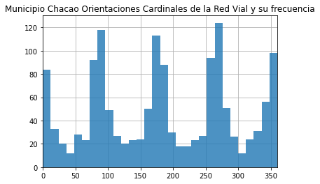

```python
G = ox.add_edge_bearings(G)
bearings = pd.Series([data['bearing'] for u, v, k, data in G.edges(keys=True, data=True)])
ax = bearings.hist(bins=30, zorder=2, alpha=0.8)
ax.set_xlim(0, 360)
ax.set_title('Municipio Chacao Orientaciones Cardinales de la Red Vial y su frecuencia')
plt.show()
```

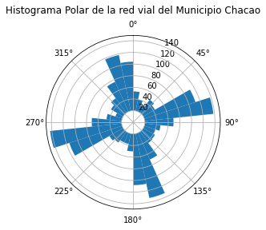

```python
n = 30
count, division = np.histogram(bearings, bins=[ang*360/n for ang in range(0,n+1)])
division = division[0:-1]
width =  2 * np.pi/n
ax = plt.subplot(111, projection='polar')
ax.set_theta_zero_location('N')
ax.set_theta_direction('clockwise')
bars = ax.bar(division * np.pi/180 - width * 0.5 , count, width=width, bottom=20.0)
ax.set_title('Histograma Polar de la red vial del Municipio Chacao', y=1.1)
plt.show()
```

Vemos para el Municipio Chacao una mayor homogeneidad que sigue la lógica de un ordenamiento geométrico de cuadrícula única con Avenidas (Norte-Sur) y Calles paralelas (Este-Oeste)

# Conclusiones

Las red vial organiza y limita la dinámica de transporte en la ciudad de acuerdo con una cierta lógica espacial, ya sea planificada o no planificada, ordenada o desordenada.

Este estudio presentó un modelo basado en los algoritmos de OSMnx para la optimización de potenciales rutas para bicicletas basadas en la logitud y la altitud de la red vial utilizando datos de OpenStreetMap y el API de GoogleMaps.

Finalmente se visualizó un histograma polar de orientaciones para descrubir por primera vez la lógica espacial de la estructura víal del Municipio Libertador de Caracas y lo comparamos con el Municipio Chacao siendo este último más ajustado a una grilla única y homogénea a diferencia d ela complejidad de la red vial del Municipio Libertador, demuestrando ambos casos que los modelos son una técnica escalable viable para medir y visualizar empíricamente la complejidad del orden espacial, ilustrando patrones en la urbanización y el transporte en Caracas.

Para una visualización dinámica del [algoritmo de OSMnx](https://mourner.github.io/road-orientation-map/#13.7/41.87636/-87.63854) es posible encontrar aquí.

## 👍👍 [Te invito a escribirme tus ideas, tus comentarios y sobre todo compartir tus opiniones🌍](https://www.linkedin.com/in/lealrlx/)